# 03-Python-Data-Structures-Batch-406

Python Data Structures

#### Data structures are a way of organizing and storing data so that they can be accessed and worked with efficiently.

```python
# See the value of multiple statements at once
#output for all commands in python jupyter notebook

from IPython.core.interactiveshell import InteractiveShell
InteractiveShell.ast_node_interactivity = "all"
```

```python
# so far we used variables to store the data
i = 15
j = 0.333
k = "python programming"
l = True

print(i,j,k,l)
print(type(i), type(j), type(k), type(l))
```

```
15 0.333 python programming True
<class 'int'> <class 'float'> <class 'str'> <class 'bool'>
```

## Python Data Structures:

Python provides several built-in collection data types for storing and organizing multiple values. The four primary collection types are:

- **List - `[]` - `<class list>`** is a collection which is `ordered`,`indexed` and `changeable`. `Allows duplicate` members.
- **Tuple - `()` - `<class tuple>`** is a collection which is `ordered`, `indexed` and `unchangeable`. `Allows duplicate` members.
- **Set - `{}` - `<class set>`** is a collection which is `unordered` and `unindexed`. `No duplicate` members.
- **Dictionary - `{key:value}` - `<class dict>`** is a collection which is `unordered`, `changeable and indexed`. `No duplicate keys`.

# List

List is a collection which is ordered and changeable, can be indexed. Allows duplicate members.

In Python lists are written with square brackets.

```python
# let's create a list with multilpe string values

mylist = ["red", "green", "blue", "orange", "orange"]
```

```python
print(mylist)
print(type(mylist))
```

```
['red', 'green', 'blue', 'orange', 'orange']
<class 'list'>
```

### Access the List items - List Indexing

- Access the list items by referring to the index number
- Access the elements in the form `list_name[i]`, where `i` is the index number and indexing starts from 0.m

```python
# help(enumerate)

# enumerate is useful for obtaining an indexed list
# enumerate on string object
list(enumerate("PTYHON")) # this will get the indexed list with each element in the strnig

# try using enumerate on a list object
list(enumerate(mylist))
```

```
[(0, 'P'), (1, 'T'), (2, 'Y'), (3, 'H'), (4, 'O'), (5, 'N')]
```

```
[(0, 'red'), (1, 'green'), (2, 'blue'), (3, 'orange'), (4, 'orange')]
```

```python
# let us quickly revist String indexing
mystr = "PYTHON"
print(len(mystr), mystr[2], mystr[1:4], mystr[-1], sep="\n")
```

```
6
T
YTH
N
```

```python
print(mylist) # # list is a sequnce of multiple values, enclosed in []
print(len(mylist))
```

```
['red', 'green', 'blue', 'orange', 'orange']
5
```

### Visualize List Indices

#### Let's revisit String index

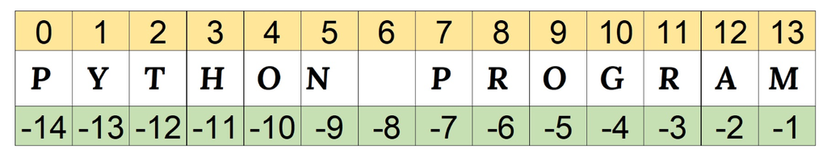

#### In the similar way, let's visuallize the List Index numbering

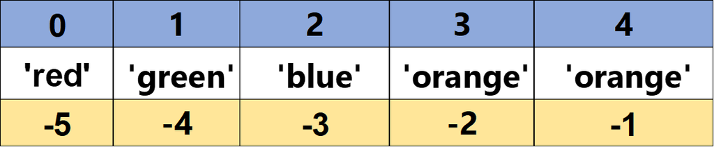

#### Internally each value or member in the list is a string

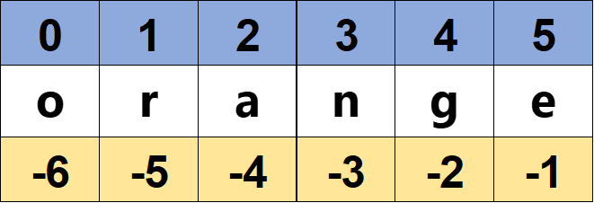

```python
print(mylist)
```

```
['red', 'green', 'blue', 'orange', 'orange']
```

```python
print(mylist[2])
print(mylist[0])
print(mylist[-1])
print(mylist[-2])

print("--"*20)

# ['red', 'green', 'blue', 'orange', 'orange']
print(mylist[2:])
print(mylist[0:2])
print(mylist[0::2])
print(mylist[::-1])
print(mylist[-2:-5:-1])

print("--"*20)

# While dealing with Data Structures,
# Observe the outcome type
print(mylist[2], type(mylist[2]),"\n", mylist[2:], type(mylist[2:]))
```

```
blue
red
orange
orange
----------------------------------------
['blue', 'orange', 'orange']
['red', 'green']
['red', 'blue', 'orange']
['orange', 'orange', 'blue', 'green', 'red']
['orange', 'blue', 'green']
----------------------------------------
blue <class 'str'>
 ['blue', 'orange', 'orange'] <class 'list'>
```

### List items are Changeable/mutable

**Lists support item assignment**

```python
# consider str item assignment
mystr
mystr[2]
mystr[2] = "t"
```

```
'PYTHON'
```

```
'T'
```

```
---------------------------------------------------------------------------
TypeError                                 Traceback (most recent call last)
Cell In[12], line 4
      2 mystr
      3 mystr[2]
----> 4 mystr[2] = "t"

TypeError: 'str' object does not support item assignment
```

```python
mylist
mylist[2]

# try item assignment on a list
mylist[2] = "BLUE"
mylist
```

```
['red', 'green', 'blue', 'orange', 'orange']
```

```
'blue'
```

```
['red', 'green', 'BLUE', 'orange', 'orange']
```

### List can hold different data types

```python
mylist1 = ['red', 'green', 'BLUE', 'orange', 'orange', True, 25,3.999999]
print(mylist1)
```

```
['red', 'green', 'BLUE', 'orange', 'orange', True, 25, 3.999999]
```

> Note: A list with different data types might not support few oprtations e.g sort

### List items can be ordered

```python
import builtins
print(dir(builtins))
```

```
['ArithmeticError', 'AssertionError', 'AttributeError', 'BaseException', 'BaseExceptionGroup', 'BlockingIOError', 'BrokenPipeError', 'BufferError', 'BytesWarning', 'ChildProcessError', 'ConnectionAbortedError', 'ConnectionError', 'ConnectionRefusedError', 'ConnectionResetError', 'DeprecationWarning'…
```

```python
help(sorted)
```

```
Help on built-in function sorted in module builtins:

sorted(iterable, /, *, key=None, reverse=False)
    Return a new list containing all items from the iterable in ascending order.

    A custom key function can be supplied to customize the sort order, and the
    reverse flag can be set to request the result in descending order.
```

```python
print(mylist)
sorted(mylist) # ascending order
sorted(mylist, reverse=True) # descending order

# try sorting mylist1
sorted(mylist1)
```

```
['red', 'green', 'BLUE', 'orange', 'orange']
```

```
['BLUE', 'green', 'orange', 'orange', 'red']
```

```
['red', 'orange', 'orange', 'green', 'BLUE']
```

```
---------------------------------------------------------------------------
TypeError                                 Traceback (most recent call last)
Cell In[17], line 6
      3 sorted(mylist, reverse=True) # descending order
      5 # try sorting mylist1
----> 6 sorted(mylist1)

TypeError: '<' not supported between instances of 'bool' and 'str'
```

### List Methods

```python
print(dir(list))
```

```
['__add__', '__class__', '__class_getitem__', '__contains__', '__delattr__', '__delitem__', '__dir__', '__doc__', '__eq__', '__format__', '__ge__', '__getattribute__', '__getitem__', '__getstate__', '__gt__', '__hash__', '__iadd__', '__imul__', '__init__', '__init_subclass__', '__iter__', '__le__', …
```

```python
# 'append', 'clear', 'copy', 'count', 'extend',
# 'index', 'insert', 'pop', 'remove', 'reverse', 'sort'
```

```python
# Get the help for a list method
help(list.append)
```

```
Help on method_descriptor:

append(self, object, /) unbound builtins.list method
    Append object to the end of the list.
```

```python
# Using list methods
mylist = ['red', 'green', 'blue', 'ORANGE', 'orange']
print(mylist)
```

```
['red', 'green', 'blue', 'ORANGE', 'orange']
```

### 1. append()

```python
# 1.append()
mylist.append("YELLOW")
print(mylist)
```

```
['red', 'green', 'blue', 'ORANGE', 'orange', 'YELLOW']
```

```python
# try appending multiple values
mylist.append("Black", "White")
print(mylist)
```

```
---------------------------------------------------------------------------
TypeError                                 Traceback (most recent call last)
Cell In[23], line 2
      1 # try appending multiple values
----> 2 mylist.append("Black", "White")
      3 print(mylist)

TypeError: list.append() takes exactly one argument (2 given)
```

```python
# try appending multiple values in a list
mylist.append(["Black", "White"])
print(mylist)

# the new list is added at the end of the existing list
# list inside a list ==> NESTED LIST
```

```
['red', 'green', 'blue', 'ORANGE', 'orange', 'YELLOW', ['Black', 'White']]
```

### 2. copy()

```python
help(list.copy)
```

```
Help on method_descriptor:

copy(self, /) unbound builtins.list method
    Return a shallow copy of the list.
```

```python
# create a new list object that contains the same elements as the other list
mylist

mylist1 = mylist

mylist1
```

```
['red', 'green', 'blue', 'ORANGE', 'orange', 'YELLOW', ['Black', 'White']]
```

```
['red', 'green', 'blue', 'ORANGE', 'orange', 'YELLOW', ['Black', 'White']]
```

```python
mylist1.append("GREEN")
```

```python
print(mylist1, mylist, sep = "\n")
```

```
['red', 'green', 'blue', 'ORANGE', 'orange', 'YELLOW', ['Black', 'White'], 'GREEN']
['red', 'green', 'blue', 'ORANGE', 'orange', 'YELLOW', ['Black', 'White'], 'GREEN']
```

```python
help(id)
```

```
Help on built-in function id in module builtins:

id(obj, /)
    Return the identity of an object.

    This is guaranteed to be unique among simultaneously existing objects.
    (CPython uses the object's memory address.)
```

```python
print(id(mylist), id(mylist1), sep="\n")
```

```
2227953321344
2227953321344
```

```python
mylist2 = mylist.copy()
```

```python
mylist2.append("Grey")
```

```python
print(mylist, mylist1, mylist2, sep="\n")
```

```
['red', 'green', 'blue', 'ORANGE', 'orange', 'YELLOW', ['Black', 'White'], 'GREEN']
['red', 'green', 'blue', 'ORANGE', 'orange', 'YELLOW', ['Black', 'White'], 'GREEN']
['red', 'green', 'blue', 'ORANGE', 'orange', 'YELLOW', ['Black', 'White'], 'GREEN', 'Grey']
```

```python
print(id(mylist), id(mylist2), sep="\n")
```

```
2227953321344
2227954065600
```

### 3. count()

```python
help(list.count)
```

```
Help on method_descriptor:

count(self, value, /) unbound builtins.list method
    Return number of occurrences of value.
```

```python
mylist
```

```
['red',
 'green',
 'blue',
 'ORANGE',
 'orange',
 'YELLOW',
 ['Black', 'White'],
 'GREEN']
```

```python
print(mylist.count("Green"))
print(mylist.count("orange"))
print(mylist.count("White"))
```

```
0
1
0
```

### 4. extend()

```python
help(list.extend)
```

```
Help on method_descriptor:

extend(self, iterable, /) unbound builtins.list method
    Extend list by appending elements from the iterable.
```

```python
mylist.extend(["Purple", "Dark Blue", "Light Blue"])
```

```python
mylist
```

```
['red',
 'green',
 'blue',
 'ORANGE',
 'orange',
 'YELLOW',
 ['Black', 'White'],
 'GREEN',
 'Purple',
 'Dark Blue',
 'Light Blue']
```

```python
# try extend with a string value
mylist.extend("BROWN")
```

```python
print(mylist)
```

```
['red', 'green', 'blue', 'ORANGE', 'orange', 'YELLOW', ['Black', 'White'], 'GREEN', 'Purple', 'Dark Blue', 'Light Blue', 'B', 'R', 'O', 'W', 'N']
```

### 5. index()

```python
help(list.index)
```

```
Help on method_descriptor:

index(self, value, start=0, stop=9223372036854775807, /) unbound builtins.list method
    Return first index of value.

    Raises ValueError if the value is not present.
```

```python
mylist.index("Purple")
```

```
8
```

```python
mylist.index("Black")
```

```
---------------------------------------------------------------------------
ValueError                                Traceback (most recent call last)
Cell In[45], line 1
----> 1 mylist.index("Black")

ValueError: 'Black' is not in list
```

### 6. insert()

```python
help(list.insert)
```

```
Help on method_descriptor:

insert(self, index, object, /) unbound builtins.list method
    Insert object before index.
```

```python
mylist
```

```
['red',
 'green',
 'blue',
 'ORANGE',
 'orange',
 'YELLOW',
 ['Black', 'White'],
 'GREEN',
 'Purple',
 'Dark Blue',
 'Light Blue',
 'B',
 'R',
 'O',
 'W',
 'N']
```

```python
mylist.insert(8, "Pink")
```

```python
print(mylist)
```

```
['red', 'green', 'blue', 'ORANGE', 'orange', 'YELLOW', ['Black', 'White'], 'GREEN', 'Pink', 'Purple', 'Dark Blue', 'Light Blue', 'B', 'R', 'O', 'W', 'N']
```

### 7. reverse()

```python
help(list.reverse)
```

```
Help on method_descriptor:

reverse(self, /) unbound builtins.list method
    Reverse *IN PLACE*.
```

```python
mylist.reverse()

# an "in-place operation" refers to an operation
# that modifies the contents of an object directly
```

```python
print(mylist)
```

```
['N', 'W', 'O', 'R', 'B', 'Light Blue', 'Dark Blue', 'Purple', 'Pink', 'GREEN', ['Black', 'White'], 'YELLOW', 'orange', 'ORANGE', 'blue', 'green', 'red']
```

### 8. sort()

```python
help(list.sort)
```

```
Help on method_descriptor:

sort(self, /, *, key=None, reverse=False) unbound builtins.list method
    Sort the list in ascending order and return None.

    The sort is in-place (i.e. the list itself is modified) and stable (i.e. the
    order of two equal elements is maintained).

    If a key function is given, apply it once to each list item and sort them,
    ascending or descending, according to their function values.

    The reverse flag can be set to sort in descending order.
```

```python
mylist3 = mylist[0:8]
```

```python
mylist3
```

```
['N', 'W', 'O', 'R', 'B', 'Light Blue', 'Dark Blue', 'Purple']
```

```python
print(id(mylist), id(mylist3))
```

```
2227953321344 2227953263936
```

```python
mylist3.sort()
```

```python
mylist3 # Ascending order by default
```

```
['B', 'Dark Blue', 'Light Blue', 'N', 'O', 'Purple', 'R', 'W']
```

```python
mylist3.sort(reverse=True)
```

```python
mylist3 # descending order
```

```
['W', 'R', 'Purple', 'O', 'N', 'Light Blue', 'Dark Blue', 'B']
```

### 9. pop()

```python
help(list.pop)
```

```
Help on method_descriptor:

pop(self, index=-1, /) unbound builtins.list method
    Remove and return item at index (default last).

    Raises IndexError if list is empty or index is out of range.
```

```python
mylist3.pop() # by default  last item will be removed
```

```
'B'
```

```python
mylist3.pop(3)
```

```
'O'
```

```python
mylist3.pop(120)
```

```
---------------------------------------------------------------------------
IndexError                                Traceback (most recent call last)
Cell In[64], line 1
----> 1 mylist3.pop(120)

IndexError: pop index out of range
```

### 10. remove()

```python
help(list.remove)
```

```
Help on method_descriptor:

remove(self, value, /) unbound builtins.list method
    Remove first occurrence of value.

    Raises ValueError if the value is not present.
```

```python
mylist3
```

```
['W', 'R', 'Purple', 'N', 'Light Blue', 'Dark Blue']
```

```python
mylist3.remove("Purple")
```

```python
mylist3
```

```
['W', 'R', 'N', 'Light Blue', 'Dark Blue']
```

```python
mylist3.remove("White")
```

```
---------------------------------------------------------------------------
ValueError                                Traceback (most recent call last)
Cell In[69], line 1
----> 1 mylist3.remove("White")

ValueError: list.remove(x): x not in list
```

### 11. clear()

```python
mylist3
```

```
['W', 'R', 'N', 'Light Blue', 'Dark Blue']
```

```python
mylist3.clear()
mylist3
```

```
[]
```